# Analiza asocjacji w R

Mateusz Dolinski

10.03.2018

# Wstep

Celem tego dokumentu jest zastosowanie analizy asocjacji do rozwiazania praktycznego problemu na zbiorze danych medycznych: na podstawie informacji o wizytach pacjentow nalezy wskazac pary chorob, ktore ‘czesto wystepuja razem’. Rozwiazanie przygotowane jest w nastepujacej formie: na poczatku przedstawiono opis danych i zastosowanego podejscia. Nastepnie krok po kroku scharakteryzowano wykonane transformacje na danych. Na koncu opisano wyniki i ich wizualizacje.

Rozwiazanie zostalo napisane w pakiecie statystycznym R przy uzyciu nastepujacych bibliotek:

- [plyr](https://cran.r-project.org/web/packages/plyr/plyr.pdf)
- [arules](https://cran.r-project.org/web/packages/arules/arules.pdf)
- [arulesViz](https://cran.r-project.org/web/packages/arulesViz/vignettes/arulesViz.pdf)
- [rainbow](https://cran.r-project.org/web/packages/rainbow/rainbow.pdf)
- [ggplot2](https://cran.r-project.org/web/packages/ggplot2/ggplot2.pdf)

# Zbior danych i podejscie do problemu

Otrzymany zbior danych jest rejestrem wizyt pacjentow. Ma on 22114 rekordow od 5000 pacjentow. Kazdy wiersz sklada sie z trzech kolumn:

- date_num - data a dokładnie dzień, ale zakodowany w postaci liczby. Im liczba mniejsza tym starsza wizyta.
- patient_id - kod pacjenta. Wiersze z tym samym kodem dotyczą tego samego pacjenta.
- rec1_code - kod choroby zapisany za pomocą Klasyfikacji Chorób [ICD 10](https://en.wikipedia.org/wiki/ICD-10)

Rozwiazaniem problemu jest odnalezienie tzw. czestych chorob (ang. *frequent itemsets*). Niech C będzie zbiorem wszystkich chorob. Powiemy, ze zbior A, będący podzbiorem C, jest zbiorem czestym o wsparciu s jezeli odsetek wszystkich pacjentow cierpiacych na choroby w zadanym zbiorze danych wynosi s. Na podstawie zbiorow czestych mozna odnalezc reguly decyzyjne. Regula decyzyjna jest to wnioskowanie postaci A => B gdzie A i B to podzbiory C. Mowimy, ze regula decyzyjna ma pewnosc c jesli stosunek wsparcia sumy zbiorow A i B do wsparcia zbioru A jest niemniejszy od c. Do znajdowania zbiorow czestych oraz regul decyzyjnych posluzy nam algorytm [apriori](https://pl.wikipedia.org/wiki/A_priori) oraz jego implementacja w bibliotece arules.

# Transformacja danych

Na poczatku wczytany zotal zbior danych:

```r
DATA <- read.csv("C:/Users/Mateusz/Downloads/zadanie0.tsv",
                 sep = "\t")
```

Nastepnie z kazdego kodu choroby wyciagnieta zostal pierwszy znak przy pomocy funkcji gsub:

```r
DATA$rec1_code <- gsub("^(.).*",
                       "\\1",
                       DATA$rec1_code,
                       perl = T)
```

```r
DATA$date_num <- NULL
write.csv(DATA, 'data_correct_format.csv', row.names = F)
DATA_APRIORI <- read.transactions('data_correct_format.csv',
                                  rm.duplicates = T,
                                  format = "single",
                                  sep = ",",
                                  cols = c(1, 2),
                                  skip = 1)
```

# Wyniki analizy asocjacji

Na obiekcie `DATA_APRIORI` zapuszczono algorytm znajdujacy czeste podzbiory chorob. Ustawiony parametr `supp` na poziomie 0.04 jest wyborem arbitralnym, choc stoi za nim pewna interpretacja: poszukujemy kodow chorob wystepujacych naraz u co najmniej 4% wszystkich pacjentow:

```r
frequent_itemsets <- eclat(DATA_APRIORI,
                           parameter = list(supp = 0.04))
```

```
Eclat

parameter specification:
 tidLists support minlen maxlen            target   ext
    FALSE    0.04      1     10 frequent itemsets FALSE

algorithmic control:
 sparse sort verbose
      7   -2    TRUE

Absolute minimum support count: 200

create itemset ...
set transactions ...[25 item(s), 5000 transaction(s)] done [0.00s].
sorting and recoding items ... [12 item(s)] done [0.00s].
creating bit matrix ... [12 row(s), 5000 column(s)] done [0.00s].
writing  ... [17 set(s)] done [0.00s].
Creating S4 object  ... done [0.00s].
```

```r
summary_frequent <- inspect(frequent_itemsets)
```

```
     items support count
[1]  {J,R} 0.0436   218
[2]  {M,Z} 0.0428   214
[3]  {N,Z} 0.0832   416
[4]  {H,J} 0.0484   242
[5]  {J,Z} 0.1124   562
[6]  {Z}   0.3568  1784
[7]  {J}   0.2708  1354
[8]  {H}   0.2042  1021
[9]  {I}   0.1822   911
[10] {N}   0.1600   800
[11] {M}   0.1300   650
[12] {K}   0.1136   568
[13] {R}   0.0806   403
[14] {L}   0.0728   364
[15] {G}   0.0572   286
[16] {E}   0.0608   304
[17] {S}   0.0406   203
```

Otrzymano 17 zbiorow spelniajacych powyzszy warunek. Sprawdzono wyniki obliczen, obliczajac na boku wsparcie dwoch losowych singletonow. Wykorzystano w tym celu funkcje `ddply()` z pakietu plyr:

```r
DATA_BASKET_FORMAT <- ddply(DATA,
                            c("patient_id"),
                            function(data_frame) {
                              paste(data_frame$rec1_code,
                                    collapse = ",")
                            })
DATA_BASKET_FORMAT$V1 <- sapply(DATA_BASKET_FORMAT$V1 ,
                                function(x) {
                                  paste(sort(unique(unlist(strsplit(x,
                                                                    split = ',')))),
                                        collapse = ',')
                                })
sprintf('Support for {Z} = %.4f',
        sum(sapply(DATA_BASKET_FORMAT[, 2],function(x) grepl('Z', x))) /
          length(unique(DATA[, 1])))
```

```
[1] "Support for {Z} = 0.3568"
```

```r
sprintf('Support for {G} = %.4f',
        sum(sapply(DATA_BASKET_FORMAT[, 2],function(x) grepl('G', x))) /
          length(unique(DATA[, 1])))
```

```
[1] "Support for {G} = 0.0572"
```

Wyniki obliczen wykonywanych przez biblioteke sa poprawne. Ponizej zamieszczono ich wizualizacje przy pomocy funkcji `itemFrequencyPlot` z biblioteki arulesViz:

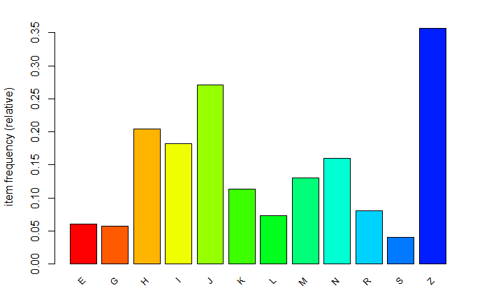

```r
rainbowcols <- rainbow(nrow(summary_frequent))
itemFrequencyPlot(DATA_APRIORI,
                  support = 0.04,
                  cex.names = 0.8,
                  col = rainbowcols)
```

Zauwazmy jednak, ze zbiory z wyniku zawieraja singletony, podczas gdy poszukiwane sa choroby wspolwystepujace. Zmodyfikowano wiec API i stworzono wlasna wizualizacje. Wykorzystano w tym celu pakiet ggplot2:

```r
summary_frequent <- summary_frequent[sapply(as.character(summary_frequent$items),
                                            nchar) > 3, ]
summary_frequent
```

|  | items | support | count |
| --- | --- | --- | --- |
| [1] | {J,R} | 0.0436 | 218 |
| [2] | {M,Z} | 0.0428 | 214 |
| [3] | {N,Z} | 0.0832 | 416 |
| [4] | {H,J} | 0.0484 | 242 |
| [5] | {J,Z} | 0.1124 | 562 |

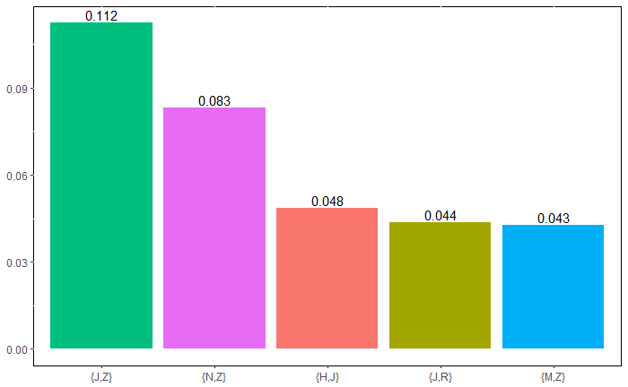

```r
summary_frequent$order <- order(summary_frequent$support,
                                decreasing = T)
ggplot(data.frame(summary_frequent),
       aes(x = reorder(items, -support),
           y = support, fill = items)) +
  geom_bar(stat = "identity") +
  geom_text(aes(label= round(support, 3)),
            position=position_dodge(width = 0.9),
            vjust = -0.25) +
  theme(panel.background = element_rect(fill = 'white',
                                        colour = 'black'),
        axis.title.x = element_blank(),
        axis.title.y = element_blank(),
        legend.position = "none")
```

Na koniec przeprowadzono analize asocjacji w celu znalezienia regul decyzyjnych o pewnosci co najmniej 50%:

```r
disease_rules <- apriori(DATA_APRIORI,
                         parameter = list(supp = 0.04,
                                          conf = 0.5,
                                          target="rules"))
```

```
Apriori

Parameter specification:
 confidence minval smax arem  aval originalSupport maxtime support minlen maxlen target   ext
        0.5    0.1    1 none FALSE            TRUE       5    0.04      1     10  rules FALSE

Algorithmic control:
 filter tree heap memopt load sort verbose
    0.1 TRUE TRUE  FALSE TRUE    2    TRUE

Absolute minimum support count: 200

set item appearances ...[0 item(s)] done [0.00s].
set transactions ...[25 item(s), 5000 transaction(s)] done [0.00s].
sorting and recoding items ... [12 item(s)] done [0.00s].
creating transaction tree ... done [0.00s].
checking subsets of size 1 2 done [0.00s].
writing ... [2 rule(s)] done [0.00s].
creating S4 object  ... done [0.00s].
```

```r
inspect(disease_rules)
```

```
    lhs    rhs support confidence lift     count
[1] {R} => {J} 0.0436  0.5409429  1.997574 218
[2] {N} => {Z} 0.0832  0.5200000  1.457399 416
```

Otrzymano 2 reguly decyzyjne. Ponizej zamieszczono ich wizualizacje:

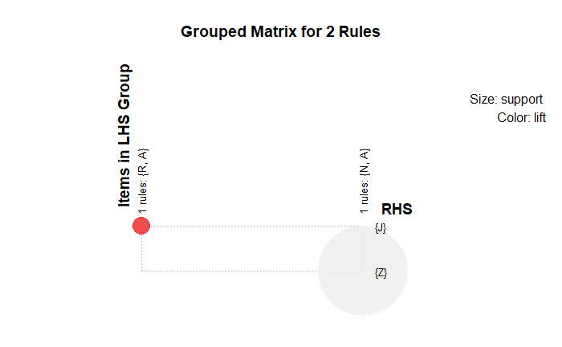

```r
plot(disease_rules,
     method = "grouped")
```

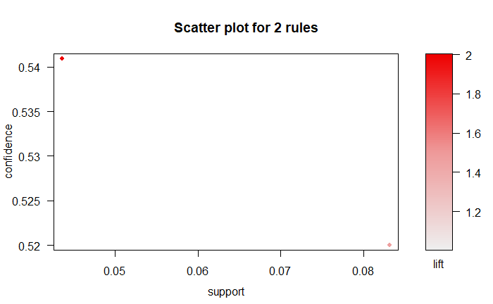

```r
plot(disease_rules)
```

# Podsumowanie

Otrzymano 5 par chorob wspolwystepujacych. Sa to:

- (J, Z)
- (H, J)
- (N, Z)
- (M, Z)
- (J, R)

oraz dwie reguly decyzyjne:

- ( R ) => (J)
- ( N ) => (Z)

Najczesciej wspolwystepujaca para chorob wystepuje u ponad 11% pacjentow. Otrzymane wyniki moga zostac odkodowane i przekazane sektorowi medycznemu.